# Social Media Advertisement Performance Analysis

## Introduction

### Background

As e-commerce becomes increasingly competitive, businesses are investing more heavily in social media advertising to attract user attention and drive engagement. Users exposed to these ads may interact through clicks, likes, comments, and shares, with the ultimate goal of converting into purchases. Given this context, it is important to evaluate the effectiveness of different campaigns, identify high-performing ones, and understand the key factors driving their success.

### Objective

We aimed to evaluate ad campaign performance and identify key drivers of conversion and ROI. We wanted to apply funnel analysis on users based on their activities, and analyze campaign performances based on CTR (Click-Through Rate), CVR (Conversion Rate), ROI (Return On Investment) and other metrics.

## Data Overview

This dataset is sourced from Kaggle: *Social Media Advertisement Performance* by Alperen Atik. (https://www.kaggle.com/datasets/alperenmyung/social-media-advertisement-performance)

The data is synthetic, and the core of this dataset is a relational database modeled around four key entities:

- **Users**: Detailed individual profiles, including age, gender, country, location, and interests, allowing for granular demographic analysis and segmentation.
- **Campaigns**: High-level campaign data, including budget, duration, and start/end dates, providing the strategic context for all ad-related activities.
- **Ads**: Specific creative assets tied to campaigns, complete with targeting parameters for age, gender, and interests.
- **Ad Events**: The central transactional log, capturing every user interaction from a simple impression to a final purchase — the key to understanding the full conversion funnel.

### Import Data

```python
import sqlite3
conn = sqlite3.connect("/Users/sitt1iu/Documents/Kris/social media ads performance/ad_campaign_db.sqlite")
```

```python
import pandas as pd
import matplotlib.pyplot as plt
import matplotlib.ticker as mticker
import seaborn as sns
```

```python
tables = pd.read_sql("SELECT name FROM sqlite_master WHERE type = 'table'", conn)
print(tables)
```

```
        name
0      users
1  campaigns
2        ads
3  ad_events
```

```python
df_users = pd.read_sql("SELECT * FROM users", conn)
df_users
```

|  | user_id | user_gender | user_age | age_group | country | location | interests |
| --- | --- | --- | --- | --- | --- | --- | --- |
| 0 | a2474 | Female | 24 | 18-24 | United Kingdom | New Mariomouth | fitness, health |
| 1 | 141e5 | Male | 21 | 18-24 | Germany | Danielsfort | food, fitness, lifestyle |
| 2 | 34db0 | Male | 27 | 25-34 | Australia | Vincentchester | fashion, news |
| 3 | 20d08 | Female | 28 | 25-34 | India | Lisaport | health, news, finance |
| 4 | 9e830 | Male | 28 | 25-34 | United States | Brownmouth | health, photography, lifestyle |
| ... | ... | ... | ... | ... | ... | ... | ... |
| 9995 | 24364 | Male | 18 | 18-24 | United States | Curtisside | travel, fashion, art |
| 9996 | 68b82 | Male | 24 | 18-24 | Mexico | Brownland | finance |
| 9997 | 39f39 | Male | 29 | 25-34 | United States | Watersburgh | health |
| 9998 | 0b8e7 | Male | 31 | 25-34 | United Kingdom | South Kenneth | art, fashion |
| 9999 | 99e3f | Male | 37 | 35-44 | Canada | New Courtneyview | fitness |

10000 rows × 7 columns

```python
df_campaigns = pd.read_sql("SELECT * FROM campaigns", conn)
df_campaigns
```

|  | campaign_id | name | start_date | end_date | duration_days | total_budget |
| --- | --- | --- | --- | --- | --- | --- |
| 0 | 1 | Campaign_1_Launch | 2025-05-25 | 2025-07-23 | 59 | 24021.32 |
| 1 | 2 | Campaign_2_Launch | 2025-04-16 | 2025-07-07 | 82 | 79342.41 |
| 2 | 3 | Campaign_3_Winter | 2025-05-04 | 2025-06-29 | 56 | 14343.25 |
| 3 | 4 | Campaign_4_Summer | 2025-06-04 | 2025-08-08 | 65 | 45326.60 |
| 4 | 5 | Campaign_5_Launch | 2025-07-11 | 2025-08-28 | 48 | 68376.69 |
| 5 | 6 | Campaign_6_Winter | 2025-06-21 | 2025-09-13 | 84 | 78607.49 |
| 6 | 7 | Campaign_7_Winter | 2025-05-25 | 2025-08-05 | 72 | 43744.59 |
| 7 | 8 | Campaign_8_Q3 | 2025-02-25 | 2025-04-07 | 41 | 39953.19 |
| 8 | 9 | Campaign_9_Launch | 2025-05-25 | 2025-07-13 | 49 | 40094.07 |
| 9 | 10 | Campaign_10_Winter | 2025-05-17 | 2025-07-21 | 65 | 19669.27 |
| 10 | 11 | Campaign_11_Q3 | 2025-04-24 | 2025-07-02 | 69 | 79067.91 |
| 11 | 12 | Campaign_12_Q3 | 2025-03-08 | 2025-06-01 | 85 | 30525.65 |
| 12 | 13 | Campaign_13_Winter | 2025-04-19 | 2025-07-01 | 73 | 21855.42 |
| 13 | 14 | Campaign_14_Summer | 2025-04-15 | 2025-06-04 | 50 | 39849.94 |
| 14 | 15 | Campaign_15_Launch | 2025-03-21 | 2025-06-11 | 82 | 85407.23 |
| 15 | 16 | Campaign_16_Winter | 2025-03-07 | 2025-06-04 | 89 | 71521.88 |
| 16 | 17 | Campaign_17_Launch | 2025-04-22 | 2025-07-18 | 87 | 86675.92 |
| 17 | 18 | Campaign_18_Q3 | 2025-04-19 | 2025-06-15 | 57 | 48832.61 |
| 18 | 19 | Campaign_19_Winter | 2025-03-06 | 2025-05-15 | 70 | 33182.45 |
| 19 | 20 | Campaign_20_Winter | 2025-02-17 | 2025-05-18 | 90 | 98904.66 |
| 20 | 21 | Campaign_21_Winter | 2025-04-19 | 2025-06-22 | 64 | 37290.81 |
| 21 | 22 | Campaign_22_Q3 | 2025-03-17 | 2025-04-22 | 36 | 35743.40 |
| 22 | 23 | Campaign_23_Winter | 2025-07-10 | 2025-10-02 | 84 | 26001.67 |
| 23 | 24 | Campaign_24_Summer | 2025-03-30 | 2025-05-23 | 54 | 56692.87 |
| 24 | 25 | Campaign_25_Winter | 2025-06-07 | 2025-09-04 | 89 | 52725.49 |
| 25 | 26 | Campaign_26_Winter | 2025-04-01 | 2025-06-17 | 77 | 44538.87 |
| 26 | 27 | Campaign_27_Q3 | 2025-02-13 | 2025-04-02 | 48 | 12986.30 |
| 27 | 28 | Campaign_28_Winter | 2025-05-09 | 2025-06-30 | 52 | 32844.79 |
| 28 | 29 | Campaign_29_Winter | 2025-07-16 | 2025-10-06 | 82 | 19773.66 |
| 29 | 30 | Campaign_30_Winter | 2025-02-25 | 2025-05-10 | 74 | 73911.29 |
| 30 | 31 | Campaign_31_Summer | 2025-05-27 | 2025-07-22 | 56 | 72208.34 |
| 31 | 32 | Campaign_32_Summer | 2025-05-02 | 2025-06-14 | 43 | 81744.53 |
| 32 | 33 | Campaign_33_Summer | 2025-04-08 | 2025-07-04 | 87 | 59264.68 |
| 33 | 34 | Campaign_34_Winter | 2025-07-10 | 2025-09-08 | 60 | 26104.30 |
| 34 | 35 | Campaign_35_Launch | 2025-07-23 | 2025-10-12 | 81 | 71626.83 |
| 35 | 36 | Campaign_36_Q3 | 2025-03-07 | 2025-05-13 | 67 | 58801.99 |
| 36 | 37 | Campaign_37_Launch | 2025-05-18 | 2025-08-01 | 75 | 46445.20 |
| 37 | 38 | Campaign_38_Q3 | 2025-04-21 | 2025-05-27 | 36 | 71038.28 |
| 38 | 39 | Campaign_39_Q3 | 2025-05-18 | 2025-07-27 | 70 | 55638.18 |
| 39 | 40 | Campaign_40_Summer | 2025-03-04 | 2025-04-20 | 47 | 53936.41 |
| 40 | 41 | Campaign_41_Winter | 2025-04-02 | 2025-06-12 | 71 | 85220.35 |
| 41 | 42 | Campaign_42_Summer | 2025-06-08 | 2025-07-25 | 47 | 7918.04 |
| 42 | 43 | Campaign_43_Winter | 2025-04-23 | 2025-06-12 | 50 | 81350.30 |
| 43 | 44 | Campaign_44_Q3 | 2025-07-14 | 2025-09-22 | 70 | 15914.87 |
| 44 | 45 | Campaign_45_Summer | 2025-05-26 | 2025-08-05 | 71 | 53303.55 |
| 45 | 46 | Campaign_46_Winter | 2025-05-10 | 2025-08-07 | 89 | 94023.76 |
| 46 | 47 | Campaign_47_Launch | 2025-06-17 | 2025-09-03 | 78 | 69493.36 |
| 47 | 48 | Campaign_48_Winter | 2025-04-08 | 2025-06-01 | 54 | 13842.07 |
| 48 | 49 | Campaign_49_Winter | 2025-02-21 | 2025-05-17 | 85 | 28962.34 |
| 49 | 50 | Campaign_50_Summer | 2025-07-02 | 2025-08-03 | 32 | 47274.70 |

```python
df_ads = pd.read_sql("SELECT * FROM ads", conn)
df_ads
```

|  | ad_id | campaign_id | ad_platform | ad_type | target_gender | target_age_group | target_interests |
| --- | --- | --- | --- | --- | --- | --- | --- |
| 0 | 1 | 28 | Facebook | Video | Female | 35-44 | art, technology |
| 1 | 2 | 33 | Facebook | Stories | All | 25-34 | travel, photography |
| 2 | 3 | 20 | Instagram | Carousel | All | 25-34 | technology |
| 3 | 4 | 28 | Facebook | Stories | Female | 25-34 | news |
| 4 | 5 | 24 | Instagram | Image | Female | 25-34 | news |
| ... | ... | ... | ... | ... | ... | ... | ... |
| 195 | 196 | 12 | Facebook | Stories | Male | 35-44 | gaming, sports |
| 196 | 197 | 9 | Facebook | Stories | All | All | lifestyle, gaming |
| 197 | 198 | 34 | Facebook | Video | All | 35-44 | fitness, lifestyle |
| 198 | 199 | 15 | Instagram | Video | Male | 25-34 | art, news |
| 199 | 200 | 44 | Instagram | Carousel | Male | 18-24 | photography |

200 rows × 7 columns

```python
df_ad_events = pd.read_sql("SELECT * FROM ad_events", conn)
df_ad_events
```

|  | event_id | ad_id | user_id | timestamp | day_of_week | time_of_day | event_type |
| --- | --- | --- | --- | --- | --- | --- | --- |
| 0 | 1 | 197 | 2359b | 2025-07-26 00:19:56 | Saturday | Night | Like |
| 1 | 2 | 51 | f9c67 | 2025-06-15 08:28:07 | Sunday | Morning | Share |
| 2 | 3 | 46 | 5b868 | 2025-06-27 00:40:02 | Friday | Night | Impression |
| 3 | 4 | 166 | 3d440 | 2025-06-05 19:20:45 | Thursday | Evening | Impression |
| 4 | 5 | 52 | 68f1a | 2025-07-22 08:30:29 | Tuesday | Morning | Impression |
| ... | ... | ... | ... | ... | ... | ... | ... |
| 399995 | 399996 | 132 | 3cb8c | 2025-08-01 22:36:54 | Friday | Evening | Impression |
| 399996 | 399997 | 200 | fe0e3 | 2025-05-31 14:53:18 | Saturday | Afternoon | Impression |
| 399997 | 399998 | 2 | a08c1 | 2025-07-27 13:39:51 | Sunday | Afternoon | Click |
| 399998 | 399999 | 109 | 4f0cf | 2025-05-16 02:38:23 | Friday | Night | Impression |
| 399999 | 400000 | 63 | 2c11d | 2025-06-15 12:06:28 | Sunday | Afternoon | Impression |

400000 rows × 7 columns

## Data Cleaning and Exploratory Data Analysis

```python
df_users.isnull().sum()
```

```
user_id        0
user_gender    0
user_age       0
age_group      0
country        0
location       0
interests      0
dtype: int64
```

```python
df_users.duplicated().sum()
```

```
np.int64(0)
```

```python
df_users.info()
```

```
<class 'pandas.core.frame.DataFrame'>
RangeIndex: 10000 entries, 0 to 9999
Data columns (total 7 columns):
 #   Column       Non-Null Count  Dtype
---  ------       --------------  -----
 0   user_id      10000 non-null  object
 1   user_gender  10000 non-null  object
 2   user_age     10000 non-null  int64
 3   age_group    10000 non-null  object
 4   country      10000 non-null  object
 5   location     10000 non-null  object
 6   interests    10000 non-null  object
dtypes: int64(1), object(6)
memory usage: 547.0+ KB
```

```python
df_campaigns.isnull().sum()
```

```
campaign_id      0
name             0
start_date       0
end_date         0
duration_days    0
total_budget     0
dtype: int64
```

```python
df_campaigns.duplicated().sum()
```

```
np.int64(0)
```

```python
df_campaigns.info()
```

```
<class 'pandas.core.frame.DataFrame'>
RangeIndex: 50 entries, 0 to 49
Data columns (total 6 columns):
 #   Column         Non-Null Count  Dtype
---  ------         --------------  -----
 0   campaign_id    50 non-null     int64
 1   name           50 non-null     object
 2   start_date     50 non-null     object
 3   end_date       50 non-null     object
 4   duration_days  50 non-null     int64
 5   total_budget   50 non-null     float64
dtypes: float64(1), int64(2), object(3)
memory usage: 2.5+ KB
```

```python
df_ads.isnull().sum()
```

```
ad_id               0
campaign_id         0
ad_platform         0
ad_type             0
target_gender       0
target_age_group    0
target_interests    0
dtype: int64
```

```python
df_ads.duplicated().sum()
```

```
np.int64(0)
```

```python
df_ads.info()
```

```
<class 'pandas.core.frame.DataFrame'>
RangeIndex: 200 entries, 0 to 199
Data columns (total 7 columns):
 #   Column            Non-Null Count  Dtype
---  ------            --------------  -----
 0   ad_id             200 non-null    int64
 1   campaign_id       200 non-null    int64
 2   ad_platform       200 non-null    object
 3   ad_type           200 non-null    object
 4   target_gender     200 non-null    object
 5   target_age_group  200 non-null    object
 6   target_interests  200 non-null    object
dtypes: int64(2), object(5)
memory usage: 11.1+ KB
```

```python
df_ad_events.isnull().sum()
```

```
event_id       0
ad_id          0
user_id        0
timestamp      0
day_of_week    0
time_of_day    0
event_type     0
dtype: int64
```

```python
df_ad_events.duplicated().sum()
```

```
np.int64(0)
```

```python
df_ad_events.info()
```

```
<class 'pandas.core.frame.DataFrame'>
RangeIndex: 400000 entries, 0 to 399999
Data columns (total 7 columns):
 #   Column       Non-Null Count   Dtype
---  ------       --------------   -----
 0   event_id     400000 non-null  int64
 1   ad_id        400000 non-null  int64
 2   user_id      400000 non-null  object
 3   timestamp    400000 non-null  object
 4   day_of_week  400000 non-null  object
 5   time_of_day  400000 non-null  object
 6   event_type   400000 non-null  object
dtypes: int64(2), object(5)
memory usage: 21.4+ MB
```

```python
df_ad_events['event_type'].unique()
```

```
array(['Like', 'Share', 'Impression', 'Purchase', 'Click', 'Comment'],
      dtype=object)
```

## Conversion Funnel

```python
df_ad_events['event_type'].value_counts()
```

```
event_type
Impression    339812
Click          40079
Like           12013
Comment         4108
Purchase        2031
Share           1957
Name: count, dtype: int64
```

As we found here share is less than purchase, so share is not a step in the buying journey. In that case, we will take share, like, comment as 'engagement', and impression, click, and purchase in the real linear funnel.

```python
# ── Funnel Analysis ── #
funnel_order = ["Impression", "Click", "Purchase"]

funnel = (df_ad_events["event_type"]
          .value_counts()
          .reindex(funnel_order)
          .reset_index())
funnel.columns = ["event_type", "count"]


funnel["conversion_%"] = (funnel["count"] / funnel["count"].iloc[0] * 100).round(2)

funnel["drop_off_%"] = (1 - funnel["count"] / funnel["count"].shift(1)).mul(100).round(2)

print(funnel)
```

```
   event_type   count  conversion_%  drop_off_%
0  Impression  339812        100.00         NaN
1       Click   40079         11.79       88.21
2    Purchase    2031          0.60       94.93
```

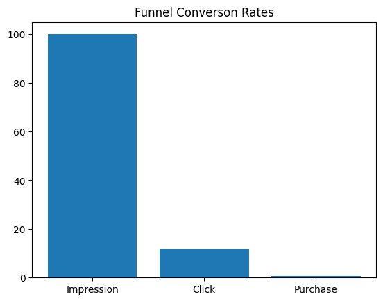

```python
rates = [100, funnel['conversion_%'][1], funnel['conversion_%'][2]]

plt.bar(funnel_order, rates)
plt.title('Funnel Converson Rates')
plt.show()
```

From impressions to clicks, the conversion rate is 11.79%, with a drop-off rate of 88.21%, suggesting that the ad’s appeal is moderate. From clicks to purchases, only 5% of users convert, indicating clear room to improve landing page performance and overall conversion. Overall, the impression-to-purchase conversion rate is 0.6%. While this falls within a typical range, the analysis above highlights meaningful opportunities to further optimize and increase conversion.

```python
# ── Engagement Analysis ── #
engagement_types = ["Like", "Comment", "Share"]
engagement = (df_ad_events["event_type"]
              .value_counts()
              .reindex(engagement_types)
              .reset_index())
engagement.columns = ["event_type", "count"]
print(engagement)
```

```
  event_type  count
0       Like  12013
1    Comment   4108
2      Share   1957
```

```python
impression_count = (df_ad_events['event_type'] == 'Impression').sum()

engagement['participation'] = (engagement['count'] / impression_count * 100).round(2)
print(engagement)
```

```
  event_type  count  participation
0       Like  12013           3.54
1    Comment   4108           1.21
2      Share   1957           0.58
```

Among users exposed to the ads, 3.54% liked, 1.21% commented, and only 0.58% shared, suggesting that the content has limited shareability. The comment rate falls within a reasonable range.

## Campaign Analysis

```python
merged = (df_ad_events
          .merge(df_ads[['ad_id', 'campaign_id']], on = 'ad_id')
          .merge(df_campaigns[['campaign_id', 'name', 'total_budget']], on = 'campaign_id'))
merged
```

|  | event_id | ad_id | user_id | timestamp | day_of_week | time_of_day | event_type | campaign_id | name | total_budget |
| --- | --- | --- | --- | --- | --- | --- | --- | --- | --- | --- |
| 0 | 1 | 197 | 2359b | 2025-07-26 00:19:56 | Saturday | Night | Like | 9 | Campaign_9_Launch | 40094.07 |
| 1 | 2 | 51 | f9c67 | 2025-06-15 08:28:07 | Sunday | Morning | Share | 26 | Campaign_26_Winter | 44538.87 |
| 2 | 3 | 46 | 5b868 | 2025-06-27 00:40:02 | Friday | Night | Impression | 10 | Campaign_10_Winter | 19669.27 |
| 3 | 4 | 166 | 3d440 | 2025-06-05 19:20:45 | Thursday | Evening | Impression | 14 | Campaign_14_Summer | 39849.94 |
| 4 | 5 | 52 | 68f1a | 2025-07-22 08:30:29 | Tuesday | Morning | Impression | 2 | Campaign_2_Launch | 79342.41 |
| ... | ... | ... | ... | ... | ... | ... | ... | ... | ... | ... |
| 399995 | 399996 | 132 | 3cb8c | 2025-08-01 22:36:54 | Friday | Evening | Impression | 1 | Campaign_1_Launch | 24021.32 |
| 399996 | 399997 | 200 | fe0e3 | 2025-05-31 14:53:18 | Saturday | Afternoon | Impression | 44 | Campaign_44_Q3 | 15914.87 |
| 399997 | 399998 | 2 | a08c1 | 2025-07-27 13:39:51 | Sunday | Afternoon | Click | 33 | Campaign_33_Summer | 59264.68 |
| 399998 | 399999 | 109 | 4f0cf | 2025-05-16 02:38:23 | Friday | Night | Impression | 8 | Campaign_8_Q3 | 39953.19 |
| 399999 | 400000 | 63 | 2c11d | 2025-06-15 12:06:28 | Sunday | Afternoon | Impression | 3 | Campaign_3_Winter | 14343.25 |

400000 rows × 10 columns

```python
campaign_stat = (merged.groupby(['campaign_id', 'name', 'total_budget'])['event_type']
                 .value_counts()
                 .unstack(fill_value = 0)
                 .reset_index())

campaign_stat
```

| event_type | campaign_id | name | total_budget | Click | Comment | Impression | Like | Purchase | Share |
| --- | --- | --- | --- | --- | --- | --- | --- | --- | --- |
| 0 | 1 | Campaign_1_Launch | 24021.32 | 578 | 50 | 5045 | 188 | 33 | 25 |
| 1 | 2 | Campaign_2_Launch | 79342.41 | 599 | 64 | 5255 | 172 | 31 | 25 |
| 2 | 3 | Campaign_3_Winter | 14343.25 | 783 | 79 | 6711 | 240 | 41 | 41 |
| 3 | 4 | Campaign_4_Summer | 45326.60 | 1178 | 121 | 10249 | 356 | 49 | 74 |
| 4 | 5 | Campaign_5_Launch | 68376.69 | 583 | 69 | 5101 | 218 | 34 | 28 |
| 5 | 6 | Campaign_6_Winter | 78607.49 | 572 | 59 | 5121 | 201 | 33 | 25 |
| 6 | 7 | Campaign_7_Winter | 43744.59 | 605 | 65 | 5002 | 184 | 33 | 32 |
| 7 | 8 | Campaign_8_Q3 | 39953.19 | 995 | 105 | 8502 | 307 | 47 | 55 |
| 8 | 9 | Campaign_9_Launch | 40094.07 | 1223 | 123 | 10343 | 347 | 61 | 42 |
| 9 | 10 | Campaign_10_Winter | 19669.27 | 763 | 79 | 6661 | 231 | 51 | 38 |
| 10 | 11 | Campaign_11_Q3 | 79067.91 | 618 | 54 | 5095 | 173 | 37 | 30 |
| 11 | 12 | Campaign_12_Q3 | 30525.65 | 441 | 38 | 3410 | 115 | 16 | 21 |
| 12 | 13 | Campaign_13_Winter | 21855.42 | 1210 | 132 | 10331 | 374 | 64 | 62 |
| 13 | 14 | Campaign_14_Summer | 39849.94 | 378 | 33 | 3313 | 118 | 22 | 21 |
| 14 | 15 | Campaign_15_Launch | 85407.23 | 1001 | 89 | 8441 | 290 | 42 | 49 |
| 15 | 17 | Campaign_17_Launch | 86675.92 | 1646 | 180 | 13506 | 470 | 91 | 91 |
| 16 | 18 | Campaign_18_Q3 | 48832.61 | 595 | 67 | 5041 | 187 | 21 | 28 |
| 17 | 19 | Campaign_19_Winter | 33182.45 | 419 | 50 | 3393 | 113 | 14 | 19 |
| 18 | 20 | Campaign_20_Winter | 98904.66 | 1658 | 156 | 13607 | 459 | 73 | 72 |
| 19 | 21 | Campaign_21_Winter | 37290.81 | 811 | 84 | 6718 | 244 | 49 | 36 |
| 20 | 22 | Campaign_22_Q3 | 35743.40 | 1084 | 101 | 8513 | 329 | 51 | 42 |
| 21 | 23 | Campaign_23_Winter | 26001.67 | 605 | 62 | 5011 | 181 | 42 | 35 |
| 22 | 24 | Campaign_24_Summer | 56692.87 | 1573 | 159 | 13638 | 451 | 81 | 87 |
| 23 | 25 | Campaign_25_Winter | 52725.49 | 998 | 100 | 8666 | 314 | 52 | 48 |
| 24 | 26 | Campaign_26_Winter | 44538.87 | 564 | 63 | 5124 | 199 | 37 | 28 |
| 25 | 27 | Campaign_27_Q3 | 12986.30 | 393 | 40 | 3323 | 128 | 33 | 22 |
| 26 | 28 | Campaign_28_Winter | 32844.79 | 608 | 75 | 5137 | 160 | 30 | 29 |
| 27 | 29 | Campaign_29_Winter | 19773.66 | 1424 | 136 | 11704 | 421 | 58 | 59 |
| 28 | 30 | Campaign_30_Winter | 73911.29 | 836 | 79 | 6780 | 232 | 42 | 38 |
| 29 | 31 | Campaign_31_Summer | 72208.34 | 589 | 65 | 5035 | 187 | 42 | 26 |
| 30 | 32 | Campaign_32_Summer | 81744.53 | 801 | 82 | 6936 | 228 | 27 | 44 |
| 31 | 33 | Campaign_33_Summer | 59264.68 | 1397 | 156 | 12043 | 409 | 85 | 75 |
| 32 | 34 | Campaign_34_Winter | 26104.30 | 1241 | 105 | 10205 | 348 | 68 | 54 |
| 33 | 35 | Campaign_35_Launch | 71626.83 | 199 | 22 | 1686 | 46 | 11 | 7 |
| 34 | 36 | Campaign_36_Q3 | 58801.99 | 409 | 45 | 3424 | 113 | 10 | 18 |
| 35 | 37 | Campaign_37_Launch | 46445.20 | 1176 | 120 | 10223 | 348 | 57 | 65 |
| 36 | 38 | Campaign_38_Q3 | 71038.28 | 1593 | 176 | 13425 | 495 | 96 | 89 |
| 37 | 39 | Campaign_39_Q3 | 55638.18 | 639 | 61 | 5162 | 181 | 27 | 29 |
| 38 | 40 | Campaign_40_Summer | 53936.41 | 823 | 84 | 6686 | 266 | 38 | 42 |
| 39 | 41 | Campaign_41_Winter | 85220.35 | 605 | 72 | 5166 | 162 | 35 | 23 |
| 40 | 42 | Campaign_42_Summer | 7918.04 | 1596 | 157 | 13671 | 465 | 67 | 74 |
| 41 | 44 | Campaign_44_Q3 | 15914.87 | 794 | 83 | 6766 | 251 | 39 | 39 |
| 42 | 45 | Campaign_45_Summer | 53303.55 | 352 | 32 | 3343 | 112 | 19 | 18 |
| 43 | 46 | Campaign_46_Winter | 94023.76 | 965 | 111 | 8517 | 308 | 36 | 58 |
| 44 | 47 | Campaign_47_Launch | 69493.36 | 1198 | 136 | 10276 | 365 | 63 | 55 |
| 45 | 48 | Campaign_48_Winter | 13842.07 | 400 | 38 | 3370 | 117 | 17 | 15 |
| 46 | 49 | Campaign_49_Winter | 28962.34 | 382 | 38 | 3430 | 119 | 18 | 17 |
| 47 | 50 | Campaign_50_Summer | 47274.70 | 179 | 13 | 1707 | 91 | 8 | 7 |

```python
campaign_stat['CTR'] = (campaign_stat['Click']/campaign_stat['Impression'] * 100).round(2)
campaign_stat['CVR'] = (campaign_stat['Purchase']/campaign_stat['Click'] * 100).round(2)
campaign_stat['ROI'] = (campaign_stat['Purchase']/campaign_stat['total_budget'] * 100).round(2) #estimated ROI due to lack of purchase amount

print(campaign_stat[["name", "CTR", "CVR", "ROI"]])
```

```
event_type                name    CTR   CVR   ROI
0            Campaign_1_Launch  11.46  5.71  0.14
1            Campaign_2_Launch  11.40  5.18  0.04
2            Campaign_3_Winter  11.67  5.24  0.29
3            Campaign_4_Summer  11.49  4.16  0.11
4            Campaign_5_Launch  11.43  5.83  0.05
5            Campaign_6_Winter  11.17  5.77  0.04
6            Campaign_7_Winter  12.10  5.45  0.08
7                Campaign_8_Q3  11.70  4.72  0.12
8            Campaign_9_Launch  11.82  4.99  0.15
9           Campaign_10_Winter  11.45  6.68  0.26
10              Campaign_11_Q3  12.13  5.99  0.05
11              Campaign_12_Q3  12.93  3.63  0.05
12          Campaign_13_Winter  11.71  5.29  0.29
13          Campaign_14_Summer  11.41  5.82  0.06
```

[output cut: 34 more lines]

We selected three metrics to evaluate campaign performance: CTR, CVR, and ROI. CTR measures how effectively the campaign captures user attention and drives clicks. CVR reflects landing page performance by indicating how many clicks convert into purchases. ROI evaluates the overall return of the campaign, assessing whether it is worth the investment relative to its budget. It is important to note that the dataset does not include direct revenue information (e.g., price or transaction value). Therefore, we use purchase count as a proxy for ROI, assuming that purchasing patterns are comparable across campaigns.

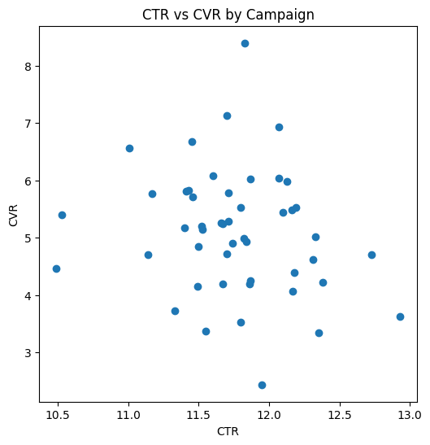

```python
plt.figure(figsize=(6,6))

plt.scatter(campaign_stat['CTR'], campaign_stat['CVR'])

plt.xlabel('CTR')
plt.ylabel('CVR')
plt.title('CTR vs CVR by Campaign')

#for i, txt in enumerate(campaign_stat['name']):
    #plt.annotate(txt, (campaign_stat['CTR'][i], campaign_stat['CVR'][i]))

plt.show()
```

### Identify the top-performing campaigns for each metric

```python
top_ctr = campaign_stat.nlargest(10, "CTR")[["name", "CTR"]]
top_cvr = campaign_stat.nlargest(10, "CVR")[["name", "CVR"]]
top_roi = campaign_stat.nlargest(10, "ROI")[["name", "ROI"]]

print("Top 10 CTR:\n", top_ctr)
print("Top 10 CVR:\n", top_cvr)
print("Top 10 ROI:\n", top_roi)
```

```
Top 10 CTR:
 event_type                name    CTR
11              Campaign_12_Q3  12.93
20              Campaign_22_Q3  12.73
37              Campaign_39_Q3  12.38
17          Campaign_19_Winter  12.35
28          Campaign_30_Winter  12.33
38          Campaign_40_Summer  12.31
15          Campaign_17_Launch  12.19
18          Campaign_20_Winter  12.18
27          Campaign_29_Winter  12.17
32          Campaign_34_Winter  12.16
Top 10 CVR:
 event_type                name   CVR
25              Campaign_27_Q3  8.40
```

[output cut: 21 more lines]

### Visualization for each metric

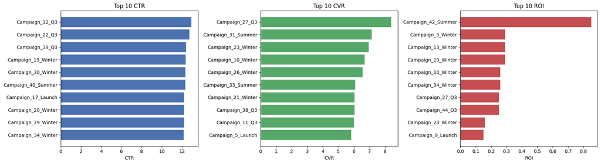

```python
fig, axes = plt.subplots(1, 3, figsize = (18, 5))

for ax, df_plot, col, title, color in zip(
        axes,
        [top_ctr, top_cvr, top_roi],
        ["CTR", "CVR", "ROI"],
        ["Top 10 CTR", "Top 10 CVR", "Top 10 ROI"],
        ["#4C72B0", "#55A868", "#C44E52"]):
    ax.barh(df_plot["name"], df_plot[col], color=color)
    ax.set_title(title)
    ax.set_xlabel(col)
    ax.invert_yaxis()

plt.tight_layout()
plt.show()
```

One key observation is that the ROI of Campaign 42 is significantly higher than that of other campaigns—nearly three times that of Campaign 3, which ranks second in terms of ROI. In terms of CVR, Campaign 27 stands out with notably stronger performance, indicating an effective landing page. Specifically, it converts approximately 8 out of every 100 clicks into purchases. By comparison, there is no substantial variation across campaigns in terms of CTR.

### Find campaigns that are good at all three metrics

```python
campaign_stat["CTR_rank"] = campaign_stat["CTR"].rank(ascending=False)
campaign_stat["CVR_rank"] = campaign_stat["CVR"].rank(ascending=False)
campaign_stat["ROI_rank"] = campaign_stat["ROI"].rank(ascending=False)

# average rank across all three
campaign_stat["overall_rank"] = (campaign_stat[["CTR_rank", "CVR_rank", "ROI_rank"]].mean(axis=1))

best_overall = campaign_stat.nsmallest(10, "overall_rank")[["name", "CTR_rank", "CVR_rank", "ROI_rank", "overall_rank"]]
print(best_overall)
```

```
event_type                name  CTR_rank  CVR_rank  ROI_rank  overall_rank
21          Campaign_23_Winter      13.5       3.0       9.0      8.500000
25              Campaign_27_Q3      20.0       1.0       7.5      9.500000
32          Campaign_34_Winter      10.0      17.0       5.5     10.833333
19          Campaign_21_Winter      13.5       7.0      16.0     12.166667
36              Campaign_38_Q3      16.5       8.0      13.0     12.500000
15          Campaign_17_Launch       7.0      15.5      21.5     14.666667
20              Campaign_22_Q3       2.0      33.0      13.0     16.000000
9           Campaign_10_Winter      39.0       4.0       5.5     16.166667
12          Campaign_13_Winter      25.5      20.0       3.0     16.166667
31          Campaign_33_Summer      32.0       6.0      13.0     17.000000
```

Here is to find out campaigns that perform well in terms of all three metrics.

### Features of top campaigns

After identifying the 10 top campaigns, we wanted to find out what features they share that make them successful.

```python
top_campaigns = campaign_stat.nsmallest(10, 'overall_rank')[['campaign_id', 'name', 'total_budget', 'CTR_rank', 'CVR_rank', 'ROI_rank', 'overall_rank']]
top_campaigns
```

| event_type | campaign_id | name | total_budget | CTR_rank | CVR_rank | ROI_rank | overall_rank |
| --- | --- | --- | --- | --- | --- | --- | --- |
| 21 | 23 | Campaign_23_Winter | 26001.67 | 13.5 | 3.0 | 9.0 | 8.500000 |
| 25 | 27 | Campaign_27_Q3 | 12986.30 | 20.0 | 1.0 | 7.5 | 9.500000 |
| 32 | 34 | Campaign_34_Winter | 26104.30 | 10.0 | 17.0 | 5.5 | 10.833333 |
| 19 | 21 | Campaign_21_Winter | 37290.81 | 13.5 | 7.0 | 16.0 | 12.166667 |
| 36 | 38 | Campaign_38_Q3 | 71038.28 | 16.5 | 8.0 | 13.0 | 12.500000 |
| 15 | 17 | Campaign_17_Launch | 86675.92 | 7.0 | 15.5 | 21.5 | 14.666667 |
| 20 | 22 | Campaign_22_Q3 | 35743.40 | 2.0 | 33.0 | 13.0 | 16.000000 |
| 9 | 10 | Campaign_10_Winter | 19669.27 | 39.0 | 4.0 | 5.5 | 16.166667 |
| 12 | 13 | Campaign_13_Winter | 21855.42 | 25.5 | 20.0 | 3.0 | 16.166667 |
| 31 | 33 | Campaign_33_Summer | 59264.68 | 32.0 | 6.0 | 13.0 | 17.000000 |

```python
top_features = top_campaigns.merge(df_ads[['campaign_id', 'ad_platform', 'ad_type', 'target_gender', 'target_age_group']], on = 'campaign_id')
top_features
```

|  | campaign_id | name | total_budget | CTR_rank | CVR_rank | ROI_rank | overall_rank | ad_platform | ad_type | target_gender | target_age_group |
| --- | --- | --- | --- | --- | --- | --- | --- | --- | --- | --- | --- |
| 0 | 23 | Campaign_23_Winter | 26001.67 | 13.5 | 3.0 | 9.0 | 8.500000 | Facebook | Video | Female | All |
| 1 | 23 | Campaign_23_Winter | 26001.67 | 13.5 | 3.0 | 9.0 | 8.500000 | Instagram | Carousel | All | 18-24 |
| 2 | 23 | Campaign_23_Winter | 26001.67 | 13.5 | 3.0 | 9.0 | 8.500000 | Instagram | Image | Male | 18-24 |
| 3 | 27 | Campaign_27_Q3 | 12986.30 | 20.0 | 1.0 | 7.5 | 9.500000 | Instagram | Stories | Female | All |
| 4 | 27 | Campaign_27_Q3 | 12986.30 | 20.0 | 1.0 | 7.5 | 9.500000 | Facebook | Carousel | Female | 35-44 |
| 5 | 34 | Campaign_34_Winter | 26104.30 | 10.0 | 17.0 | 5.5 | 10.833333 | Instagram | Stories | All | 35-44 |
| 6 | 34 | Campaign_34_Winter | 26104.30 | 10.0 | 17.0 | 5.5 | 10.833333 | Instagram | Carousel | Male | All |
| 7 | 34 | Campaign_34_Winter | 26104.30 | 10.0 | 17.0 | 5.5 | 10.833333 | Instagram | Image | Female | All |
| 8 | 34 | Campaign_34_Winter | 26104.30 | 10.0 | 17.0 | 5.5 | 10.833333 | Instagram | Stories | Female | 18-24 |
| 9 | 34 | Campaign_34_Winter | 26104.30 | 10.0 | 17.0 | 5.5 | 10.833333 | Facebook | Carousel | All | 35-44 |
| 10 | 34 | Campaign_34_Winter | 26104.30 | 10.0 | 17.0 | 5.5 | 10.833333 | Facebook | Video | All | 35-44 |
| 11 | 21 | Campaign_21_Winter | 37290.81 | 13.5 | 7.0 | 16.0 | 12.166667 | Instagram | Image | Female | 35-44 |
| 12 | 21 | Campaign_21_Winter | 37290.81 | 13.5 | 7.0 | 16.0 | 12.166667 | Facebook | Image | Female | 25-34 |
| 13 | 21 | Campaign_21_Winter | 37290.81 | 13.5 | 7.0 | 16.0 | 12.166667 | Facebook | Stories | All | All |
| 14 | 21 | Campaign_21_Winter | 37290.81 | 13.5 | 7.0 | 16.0 | 12.166667 | Facebook | Stories | Male | All |
| 15 | 38 | Campaign_38_Q3 | 71038.28 | 16.5 | 8.0 | 13.0 | 12.500000 | Instagram | Image | Male | 35-44 |
| 16 | 38 | Campaign_38_Q3 | 71038.28 | 16.5 | 8.0 | 13.0 | 12.500000 | Facebook | Carousel | All | 25-34 |
| 17 | 38 | Campaign_38_Q3 | 71038.28 | 16.5 | 8.0 | 13.0 | 12.500000 | Facebook | Carousel | Female | All |
| 18 | 38 | Campaign_38_Q3 | 71038.28 | 16.5 | 8.0 | 13.0 | 12.500000 | Facebook | Stories | All | 35-44 |
| 19 | 38 | Campaign_38_Q3 | 71038.28 | 16.5 | 8.0 | 13.0 | 12.500000 | Instagram | Carousel | All | 35-44 |
| 20 | 38 | Campaign_38_Q3 | 71038.28 | 16.5 | 8.0 | 13.0 | 12.500000 | Facebook | Stories | Female | 18-24 |
| 21 | 38 | Campaign_38_Q3 | 71038.28 | 16.5 | 8.0 | 13.0 | 12.500000 | Facebook | Carousel | All | 25-34 |
| 22 | 38 | Campaign_38_Q3 | 71038.28 | 16.5 | 8.0 | 13.0 | 12.500000 | Facebook | Carousel | All | 35-44 |
| 23 | 17 | Campaign_17_Launch | 86675.92 | 7.0 | 15.5 | 21.5 | 14.666667 | Facebook | Stories | Female | 18-24 |
| 24 | 17 | Campaign_17_Launch | 86675.92 | 7.0 | 15.5 | 21.5 | 14.666667 | Instagram | Image | Female | 35-44 |
| 25 | 17 | Campaign_17_Launch | 86675.92 | 7.0 | 15.5 | 21.5 | 14.666667 | Facebook | Image | All | 18-24 |
| 26 | 17 | Campaign_17_Launch | 86675.92 | 7.0 | 15.5 | 21.5 | 14.666667 | Instagram | Image | Female | 18-24 |
| 27 | 17 | Campaign_17_Launch | 86675.92 | 7.0 | 15.5 | 21.5 | 14.666667 | Instagram | Carousel | Female | 25-34 |
| 28 | 17 | Campaign_17_Launch | 86675.92 | 7.0 | 15.5 | 21.5 | 14.666667 | Facebook | Image | Male | All |
| 29 | 17 | Campaign_17_Launch | 86675.92 | 7.0 | 15.5 | 21.5 | 14.666667 | Facebook | Image | Male | 25-34 |
| 30 | 17 | Campaign_17_Launch | 86675.92 | 7.0 | 15.5 | 21.5 | 14.666667 | Facebook | Video | Female | All |
| 31 | 22 | Campaign_22_Q3 | 35743.40 | 2.0 | 33.0 | 13.0 | 16.000000 | Instagram | Video | All | 25-34 |
| 32 | 22 | Campaign_22_Q3 | 35743.40 | 2.0 | 33.0 | 13.0 | 16.000000 | Facebook | Video | All | All |
| 33 | 22 | Campaign_22_Q3 | 35743.40 | 2.0 | 33.0 | 13.0 | 16.000000 | Facebook | Stories | Female | 35-44 |
| 34 | 22 | Campaign_22_Q3 | 35743.40 | 2.0 | 33.0 | 13.0 | 16.000000 | Facebook | Stories | Female | All |
| 35 | 22 | Campaign_22_Q3 | 35743.40 | 2.0 | 33.0 | 13.0 | 16.000000 | Facebook | Image | Female | 25-34 |
| 36 | 10 | Campaign_10_Winter | 19669.27 | 39.0 | 4.0 | 5.5 | 16.166667 | Instagram | Carousel | All | 35-44 |
| 37 | 10 | Campaign_10_Winter | 19669.27 | 39.0 | 4.0 | 5.5 | 16.166667 | Facebook | Stories | All | 35-44 |
| 38 | 10 | Campaign_10_Winter | 19669.27 | 39.0 | 4.0 | 5.5 | 16.166667 | Facebook | Carousel | Female | 35-44 |
| 39 | 10 | Campaign_10_Winter | 19669.27 | 39.0 | 4.0 | 5.5 | 16.166667 | Facebook | Stories | Female | 35-44 |
| 40 | 13 | Campaign_13_Winter | 21855.42 | 25.5 | 20.0 | 3.0 | 16.166667 | Facebook | Carousel | All | 25-34 |
| 41 | 13 | Campaign_13_Winter | 21855.42 | 25.5 | 20.0 | 3.0 | 16.166667 | Facebook | Stories | Female | 25-34 |
| 42 | 13 | Campaign_13_Winter | 21855.42 | 25.5 | 20.0 | 3.0 | 16.166667 | Facebook | Stories | Female | 18-24 |
| 43 | 13 | Campaign_13_Winter | 21855.42 | 25.5 | 20.0 | 3.0 | 16.166667 | Instagram | Stories | All | 25-34 |
| 44 | 13 | Campaign_13_Winter | 21855.42 | 25.5 | 20.0 | 3.0 | 16.166667 | Instagram | Stories | Male | All |
| 45 | 13 | Campaign_13_Winter | 21855.42 | 25.5 | 20.0 | 3.0 | 16.166667 | Instagram | Video | All | 25-34 |
| 46 | 33 | Campaign_33_Summer | 59264.68 | 32.0 | 6.0 | 13.0 | 17.000000 | Facebook | Stories | All | 25-34 |
| 47 | 33 | Campaign_33_Summer | 59264.68 | 32.0 | 6.0 | 13.0 | 17.000000 | Facebook | Video | Male | 25-34 |
| 48 | 33 | Campaign_33_Summer | 59264.68 | 32.0 | 6.0 | 13.0 | 17.000000 | Facebook | Image | All | 18-24 |
| 49 | 33 | Campaign_33_Summer | 59264.68 | 32.0 | 6.0 | 13.0 | 17.000000 | Facebook | Stories | Female | 18-24 |
| 50 | 33 | Campaign_33_Summer | 59264.68 | 32.0 | 6.0 | 13.0 | 17.000000 | Facebook | Carousel | All | 18-24 |
| 51 | 33 | Campaign_33_Summer | 59264.68 | 32.0 | 6.0 | 13.0 | 17.000000 | Instagram | Video | Female | 18-24 |
| 52 | 33 | Campaign_33_Summer | 59264.68 | 32.0 | 6.0 | 13.0 | 17.000000 | Facebook | Image | Male | 18-24 |

```python
print(top_features["ad_platform"].value_counts())
print(top_features["ad_type"].value_counts())
print(top_features["target_gender"].value_counts())
print(top_features["target_age_group"].value_counts())
```

```
ad_platform
Facebook     34
Instagram    19
Name: count, dtype: int64
ad_type
Stories     18
Carousel    14
Image       13
Video        8
Name: count, dtype: int64
target_gender
Female    23
All       21
Male       9
Name: count, dtype: int64
target_age_group
35-44    15
18-24    13
25-34    13
All      12
Name: count, dtype: int64
```

Next, we wanted to verify whether season or campaign budgets affect the performance of campaigns.

```python
campaign_stat["season"] = campaign_stat["name"].str.extract(r'Campaign_\d+_(\w+)')
```

```python
campaign_stat['season'].value_counts()
```

```
season
Winter    19
Summer    10
Q3        10
Launch     9
Name: count, dtype: int64
```

```python
top_campaigns['season'] = campaign_stat['name'].str.extract(r'Campaign_\d+_(\w+)')
top_campaigns['season'].value_counts()
```

```
season
Winter    5
Q3        3
Launch    1
Summer    1
Name: count, dtype: int64
```

```python
season_total = campaign_stat['season'].value_counts()
season_top = top_campaigns['season'].value_counts()
season_ratio = pd.DataFrame({
    'total': season_total,
    'top': season_top
}).fillna(0)

season_ratio['ratio'] = (season_ratio['top']/season_ratio['total'] * 100).round(2)
season_ratio = season_ratio.sort_values('ratio', ascending = False)
season_ratio
```

| season | total | top | ratio |
| --- | --- | --- | --- |
| Q3 | 10 | 3 | 30.00 |
| Winter | 19 | 5 | 26.32 |
| Launch | 9 | 1 | 11.11 |
| Summer | 10 | 1 | 10.00 |

We checked the ratio of seasons in top campaigns to seasons in total campaigns. It looks like Q3 is more effective in advertising campaigns, but to validate this, more data will be needed to conduct statistical tests for more robust conclusions.

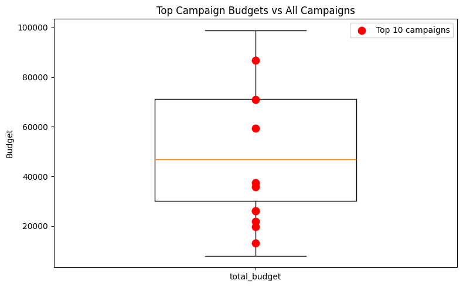

```python
top_campaigns = campaign_stat.nsmallest(10, "overall_rank")

fig, ax = plt.subplots(figsize=(8, 5))


ax.boxplot(campaign_stat["total_budget"], positions=[1], widths=0.5)


ax.scatter([1] * len(top_campaigns), top_campaigns["total_budget"],
           color="red", zorder=5, label="Top 10 campaigns", s=80)

ax.set_xticks([1])
ax.set_xticklabels(["total_budget"])
ax.set_ylabel("Budget")
ax.set_title("Top Campaign Budgets vs All Campaigns")
ax.legend()

plt.tight_layout()
plt.show()
```

Top performing campaigns do not show significant patterns in terms of budget, season, platform, or targeting — suggesting that in this dataset, campaign performance is relatively evenly distributed across these features.

## Segment Analysis

### Which social media platform performs best?

```python
merged_platform = (df_ad_events
                   .merge(df_ads[["ad_id", "ad_platform"]], on="ad_id"))


platform_stats = (merged_platform.groupby(["ad_platform", "event_type"])
                  .size()
                  .unstack(fill_value=0)
                  .reset_index())


platform_stats["CTR"] = (platform_stats["Click"] / platform_stats["Impression"] * 100).round(2)
platform_stats["CVR"] = (platform_stats["Purchase"] / platform_stats["Click"] * 100).round(2)

print(platform_stats[["ad_platform", "Impression", "Click", "Purchase", "CTR", "CVR"]])
```

```
event_type ad_platform  Impression  Click  Purchase    CTR   CVR
0             Facebook      215972  25389      1323  11.76  5.21
1            Instagram      123840  14690       708  11.86  4.82
```

The analysis of CTR and CVR shows no significant performance difference between Facebook and Instagram.

### Which user demographics engage the most?

```python
merged_users = (df_ad_events
                .merge(df_users[["user_id", "user_gender", "age_group", "country"]], on="user_id"))
gender_stats = (merged_users.groupby(['user_gender', 'event_type'])
                .size()
                .unstack(fill_value = 0)
                .reset_index())
gender_stats['CTR'] = (gender_stats['Click'] / gender_stats['Impression'] * 100).round(2)
gender_stats['CVR'] = (gender_stats['Purchase'] / gender_stats['Click'] * 100).round(2)

print(gender_stats[["user_gender", "Impression", "Click", "Purchase", "CTR", "CVR"]])
```

```
event_type user_gender  Impression  Click  Purchase    CTR   CVR
0               Female      117722  13997       719  11.89  5.14
1                 Male      190329  22326      1123  11.73  5.03
2                Other       35106   4172       208  11.88  4.99
```

```python
age_stats = (merged_users.groupby(['age_group', 'event_type'])
             .size()
             .unstack(fill_value = 0)
             .reset_index())
age_stats['CTR'] = (age_stats['Click'] / age_stats['Impression'] * 100).round(2)
age_stats['CVR'] = (age_stats['Purchase'] / age_stats['Click'] * 100).round(2)

print(age_stats[["age_group", "Impression", "Click", "Purchase", "CTR", "CVR"]])
```

```
event_type age_group  Impression  Click  Purchase    CTR   CVR
0              16-17       30156   3536       159  11.73  4.50
1              18-24      106744  12532       644  11.74  5.14
2              25-34      142248  16855       857  11.85  5.08
3              35-44       50020   5885       307  11.77  5.22
4              45-54       11134   1348        66  12.11  4.90
5              55-65        2855    339        17  11.87  5.01
```

```python
country_stats = (merged_users.groupby(['country', 'event_type'])
             .size()
             .unstack(fill_value = 0)
             .reset_index())
country_stats['CTR'] = (country_stats['Click'] / country_stats['Impression'] * 100).round(2)
country_stats['CVR'] = (country_stats['Purchase'] / country_stats['Click'] * 100).round(2)

print(country_stats[["country", "Impression", "Click", "Purchase", "CTR", "CVR"]])
```

```
event_type         country  Impression  Click  Purchase    CTR   CVR
0                Australia       24476   2946       127  12.04  4.31
1                   Brazil       20909   2439       119  11.66  4.88
2                   Canada       34488   4086       201  11.85  4.92
3                   France       13056   1502        62  11.50  4.13
4                  Germany       28167   3310       152  11.75  4.59
5                    India       32125   3873       189  12.06  4.88
6                    Japan       16812   1961       127  11.66  6.48
7                   Mexico       17803   2059       127  11.57  6.17
8           United Kingdom       51761   6027       290  11.64  4.81
9            United States      103560  12292       656  11.87  5.34
```

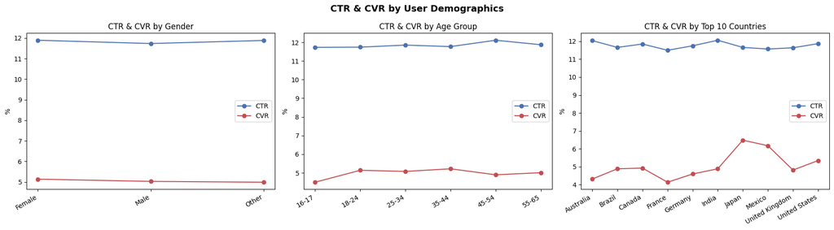

```python
fig, axes = plt.subplots(1, 3, figsize=(18, 5))

for ax, df_plot, group_col, title in zip(
        axes,
        [gender_stats, age_stats, country_stats],
        ["user_gender", "age_group", "country"],
        ["Gender", "Age Group", "Top 10 Countries"]):

    x = range(len(df_plot))
    width = 0.35

    ax.plot(df_plot[group_col], df_plot["CTR"], marker='o', label="CTR", color="#4C72B0")
    ax.plot(df_plot[group_col], df_plot["CVR"], marker='o', label="CVR", color="#C44E52")

    ax.set_xticks(list(x))
    ax.set_xticklabels(df_plot[group_col], rotation=30, ha="right")
    ax.set_ylabel("%")
    ax.set_title(f"CTR & CVR by {title}")
    ax.legend()

plt.suptitle("CTR & CVR by User Demographics", fontsize=14, fontweight="bold")
plt.tight_layout()
plt.show()
```

Plotting CTR and CVR across three demographic dimensions on the same scale, we can see that gender shows no meaningful difference in either metric. By age group, there is slight variation but no clear trend emerges. However, there is a noticeable increase in CVR in Japan and Mexico, suggesting that either the landing page experience is more effective in these markets, or users there are more inclined to purchase after clicking.

### Temporal Patterns in User Engagement

```python
tod_stats = (df_ad_events.groupby(["time_of_day", "event_type"])
             .size()
             .unstack(fill_value=0)
             .reset_index())

tod_stats
```

| event_type | time_of_day | Click | Comment | Impression | Like | Purchase | Share |
| --- | --- | --- | --- | --- | --- | --- | --- |
| 0 | Afternoon | 10140 | 1032 | 85111 | 2996 | 501 | 438 |
| 1 | Evening | 10048 | 1001 | 84919 | 3012 | 497 | 525 |
| 2 | Morning | 9963 | 1070 | 84887 | 2981 | 526 | 487 |
| 3 | Night | 9928 | 1005 | 84895 | 3024 | 507 | 507 |

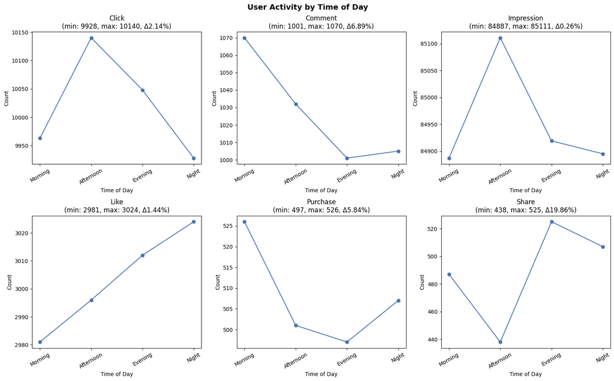

```python
tod_order = ["Morning", "Afternoon", "Evening", "Night"]
tod_stats = tod_stats.set_index("time_of_day").reindex(tod_order).reset_index()

event_cols = ["Click", "Comment", "Impression", "Like", "Purchase", "Share"]

fig, axes = plt.subplots(2, 3, figsize=(16, 10))

for ax, col in zip(axes.flatten(), event_cols):
    ax.plot(tod_stats["time_of_day"], tod_stats[col], marker='o', color="#4C72B0")
    min_val = tod_stats[col].min()
    max_val = tod_stats[col].max()
    change = round((max_val - min_val) / min_val * 100, 2)

    ax.set_title(f"{col}\n(min: {min_val}, max: {max_val}, Δ{change}%)")
    ax.set_xlabel("Time of Day")
    ax.set_ylabel("Count")
    ax.tick_params(axis="x", rotation=30)

plt.suptitle("User Activity by Time of Day", fontsize=14, fontweight="bold")
plt.tight_layout()
plt.show()
```

We examined whether user activity varies significantly across different times of day. Impressions and likes remain relatively stable throughout the day. Comments and purchases peak in the morning, while clicks reach their highest point in the afternoon — also the lowest point for shares. In the evening, shares increase notably while comments and purchases decline. At night, clicks and comments are low, though some users continue to share and purchase.

```python
week_stats = (df_ad_events.groupby(["day_of_week", "event_type"])
             .size()
             .unstack(fill_value=0)
             .reset_index())

week_stats
```

| event_type | day_of_week | Click | Comment | Impression | Like | Purchase | Share |
| --- | --- | --- | --- | --- | --- | --- | --- |
| 0 | Friday | 5828 | 600 | 48759 | 1638 | 308 | 270 |
| 1 | Monday | 5668 | 596 | 48597 | 1782 | 292 | 315 |
| 2 | Saturday | 5704 | 568 | 48460 | 1712 | 295 | 288 |
| 3 | Sunday | 5755 | 600 | 48426 | 1672 | 281 | 256 |
| 4 | Thursday | 5626 | 601 | 48598 | 1726 | 314 | 283 |
| 5 | Tuesday | 5768 | 581 | 48474 | 1733 | 268 | 257 |
| 6 | Wednesday | 5730 | 562 | 48498 | 1750 | 273 | 288 |

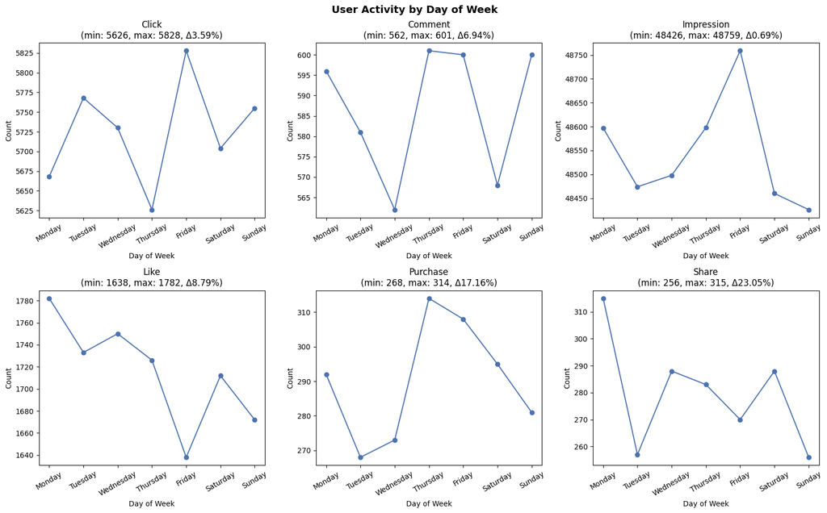

```python
week_order = ["Monday", "Tuesday", "Wednesday", "Thursday", "Friday", "Saturday", "Sunday"]
week_stats = week_stats.set_index("day_of_week").reindex(week_order).reset_index()

event_cols = ["Click", "Comment", "Impression", "Like", "Purchase", "Share"]

fig, axes = plt.subplots(2, 3, figsize=(16, 10))

for ax, col in zip(axes.flatten(), event_cols):
    ax.plot(week_stats["day_of_week"], week_stats[col], marker='o', color="#4C72B0")
    min_val = week_stats[col].min()
    max_val = week_stats[col].max()
    change = round((max_val - min_val) / min_val * 100, 2)

    ax.set_title(f"{col}\n(min: {min_val}, max: {max_val}, Δ{change}%)")
    ax.set_xlabel("Day of Week")
    ax.set_ylabel("Count")
    ax.tick_params(axis="x", rotation=30)

plt.suptitle("User Activity by Day of Week", fontsize=14, fontweight="bold")
plt.tight_layout()
plt.show()
```

## Key insights

This analysis examined social media ad performance across four dimensions: conversion funnel, campaign metrics, user demographics, and temporal patterns. Key findings are as follows:

**1. Conversion funnel highlights a critical drop-off at the click-to-purchase stage.** The overall impression-to-purchase conversion rate is 0.6%, which falls within a typical range. However, only 5% of users who clicked went on to purchase, suggesting that landing page experience and post-click conversion are the primary areas for improvement.

**2. Campaign performance varies most in CVR and ROI, not CTR.** CTR is relatively consistent across all campaigns, while CVR and ROI show more meaningful variation. Campaign 42 stands out with an exceptionally high ROI, and Campaign 27 leads in CVR, converting approximately 8 out of every 100 clicks into purchases.

**3. No strong patterns found in top campaign features.** Top-performing campaigns are distributed across platforms, ad types, target genders, and age groups, with no single feature consistently associated with better performance. Budget size also shows no clear relationship with campaign success. Q3 campaigns show a slightly higher representation among top performers, but this requires further statistical validation.

**4. Platform and demographic differences are largely insignificant.** Facebook and Instagram show comparable CTR and CVR. Gender and age group also show no meaningful difference in performance. A notable exception is Japan and Mexico, where CVR is higher than average, suggesting these markets may warrant closer attention.

**Limitations**: This dataset is entirely synthetic, which means the patterns observed may not reflect real-world advertising dynamics. Statistical tests (e.g., t-tests, chi-square) were not conducted, so findings should be treated as exploratory rather than conclusive.